# Social_Media_Final

# Density plots for all variables

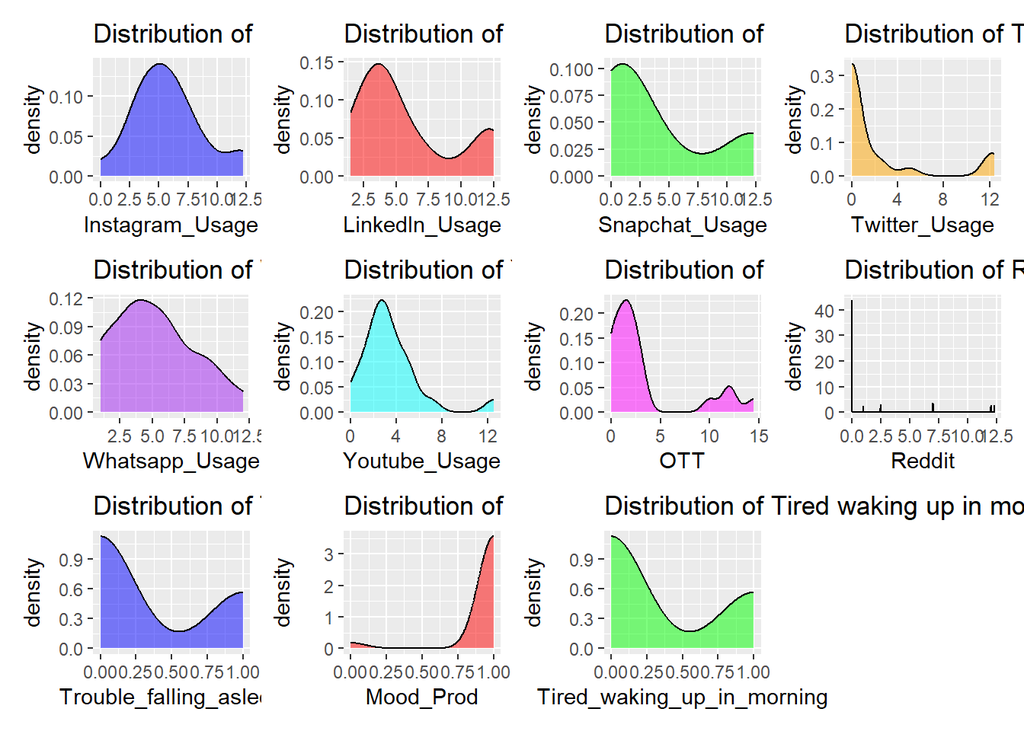

```r
library(ggplot2)
library(patchwork)
# Density plots for all variables
plot_instagram <- ggplot(social_media_final, aes(x = Instagram_Usage)) +
  geom_density(fill = "blue", alpha = 0.5) +
  labs(title = "Distribution of Instagram Usage")

plot_linkedin <- ggplot(social_media_final, aes(x = LinkedIn_Usage)) +
  geom_density(fill = "red", alpha = 0.5) +
  labs(title = "Distribution of LinkedIn Usage")

plot_snapchat <- ggplot(social_media_final, aes(x = Snapchat_Usage)) +
  geom_density(fill = "green", alpha = 0.5) +
  labs(title = "Distribution of Snapchat Usage")

plot_twitter <- ggplot(social_media_final, aes(x = Twitter_Usage)) +
  geom_density(fill = "orange", alpha = 0.5) +
  labs(title = "Distribution of Twitter Usage")

plot_whatsapp <- ggplot(social_media_final, aes(x = Whatsapp_Usage)) +
  geom_density(fill = "purple", alpha = 0.5) +
  labs(title = "Distribution of Whatsapp Usage")

plot_youtube <- ggplot(social_media_final, aes(x = Youtube_Usage)) +
  geom_density(fill = "cyan", alpha = 0.5) +
  labs(title = "Distribution of Youtube Usage")

plot_ott <- ggplot(social_media_final, aes(x = OTT)) +
  geom_density(fill = "magenta", alpha = 0.5) +
  labs(title = "Distribution of OTT Usage")

plot_reddit <- ggplot(social_media_final, aes(x = Reddit)) +
  geom_density(fill = "yellow", alpha = 0.5) +
  labs(title = "Distribution of Reddit Usage")

plot_trouble <- ggplot(social_media_final, aes(x = Trouble_falling_asleep)) +
  geom_density(fill = "blue", alpha = 0.5) +
  labs(title = "Distribution of Trouble falling asleep")

plot_mood <- ggplot(social_media_final, aes(x = Mood_Prod)) +
  geom_density(fill = "red", alpha = 0.5) +
  labs(title = "Distribution of Mood Productivity")

plot_tired <- ggplot(social_media_final, aes(x = Tired_waking_up_in_morning)) +
  geom_density(fill = "green", alpha = 0.5) +
  labs(title = "Distribution of Tired waking up in morning")

# Combine plots using patchwork
combined_plots <- plot_instagram + plot_linkedin + plot_snapchat + plot_twitter +
  plot_whatsapp + plot_youtube + plot_ott + plot_reddit + plot_trouble +
  plot_mood + plot_tired

# Print combined plots
combined_plots
```

# Count the occurrences of each category in the dependent variables

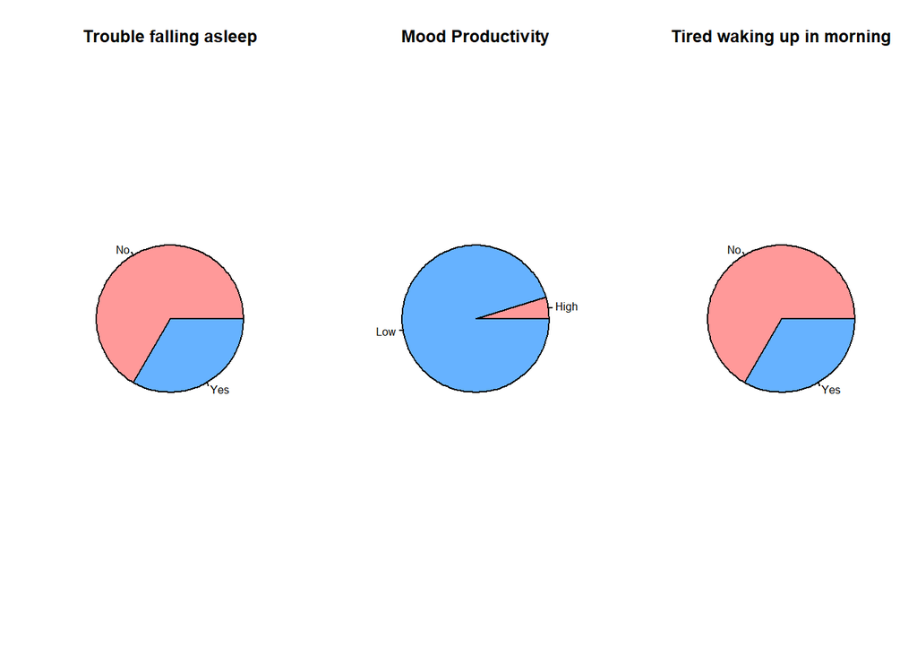

```r
trouble_falling_asleep_counts <- table(social_media_final$Trouble_falling_asleep)
mood_prod_counts <- table(social_media_final$Mood_Prod)
tired_waking_up_counts <- table(social_media_final$Tired_waking_up_in_morning)

# Create a color palette for the pie charts
colors <- c("#FF9999", "#66B2FF")

# Create pie charts for each variable with better visualization
par(mfrow = c(1, 3))  # Arrange plots in a 1x3 grid

# Pie chart for Trouble falling asleep
pie(trouble_falling_asleep_counts,
    main = "Trouble falling asleep",
    col = colors,
    labels = c("No", "Yes"),
    cex = 0.8)  # Adjust label size

# Pie chart for Mood Productivity
pie(mood_prod_counts,
    main = "Mood Productivity",
    col = colors,
    labels = c("High", "Low"),
    cex = 0.8)  # Adjust label size

# Pie chart for Tired waking up in morning
pie(tired_waking_up_counts,
    main = "Tired waking up in morning",
    col = colors,
    labels = c("No", "Yes"),
    cex = 0.8)  # Adjust label size
```

# Count the occurrences of each category in the dependent variables

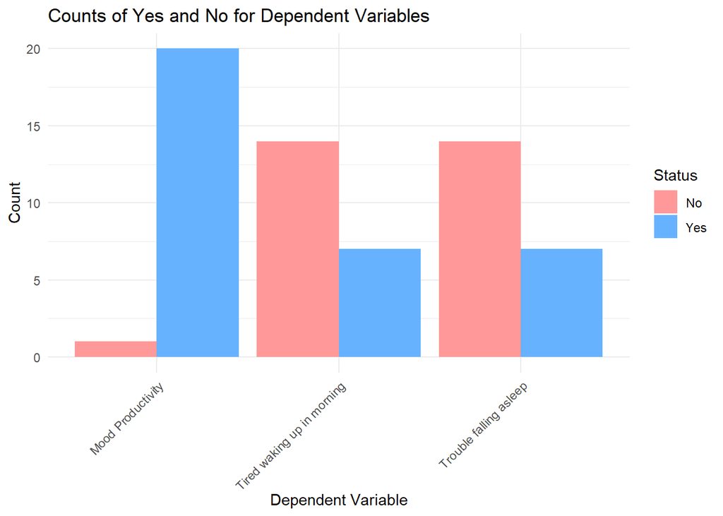

```r
trouble_falling_asleep_counts <- table(social_media_final$Trouble_falling_asleep)
mood_prod_counts <- table(social_media_final$Mood_Prod)
tired_waking_up_counts <- table(social_media_final$Tired_waking_up_in_morning)

# Create a data frame for plotting
data <- data.frame(
  Variable = c("Trouble falling asleep", "Mood Productivity", "Tired waking up in morning"),
  Yes = c(trouble_falling_asleep_counts[2], mood_prod_counts[2], tired_waking_up_counts[2]),
  No = c(trouble_falling_asleep_counts[1], mood_prod_counts[1], tired_waking_up_counts[1])
)

# Reshape the data for plotting
library(tidyr)
data_long <- pivot_longer(data, cols = c("Yes", "No"), names_to = "Status", values_to = "Count")

# Plot the bar plot
library(ggplot2)
ggplot(data_long, aes(x = Variable, y = Count, fill = Status)) +
  geom_bar(stat = "identity", position = "dodge") +
  labs(title = "Counts of Yes and No for Dependent Variables",
       x = "Dependent Variable",
       y = "Count") +
  scale_fill_manual(values = c("#FF9999", "#66B2FF")) +  # Custom colors for Yes and No
  theme_minimal() +
  theme(axis.text.x = element_text(angle = 45, hjust = 1))  # Rotate x-axis labels for better readability
```

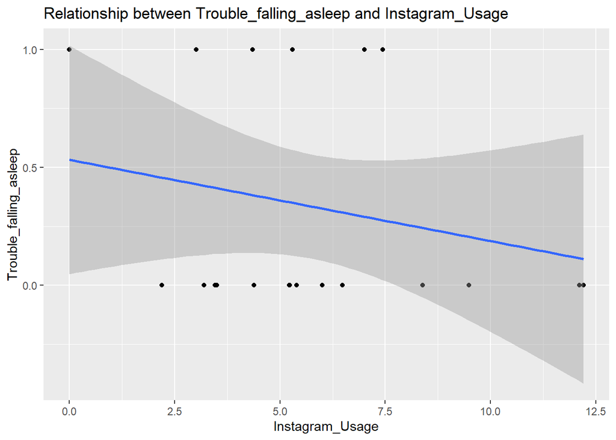

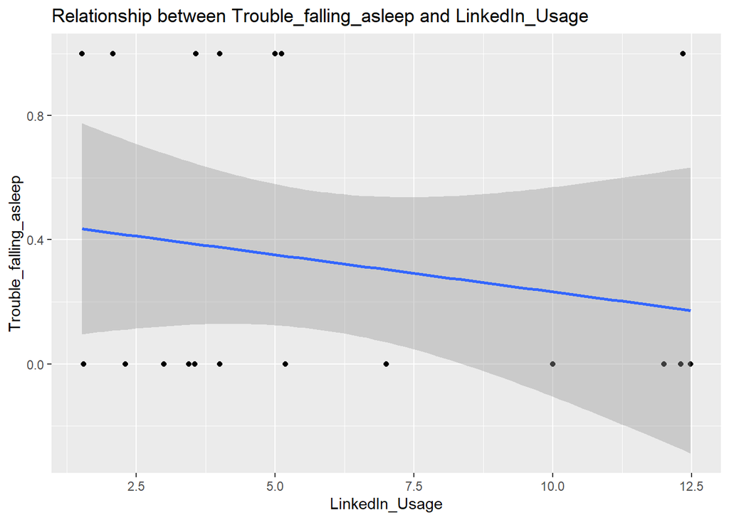

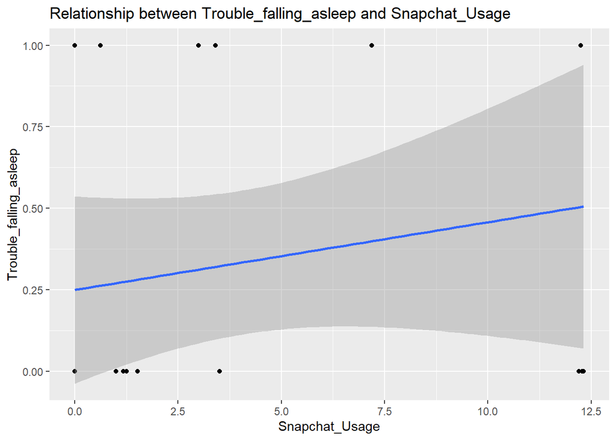

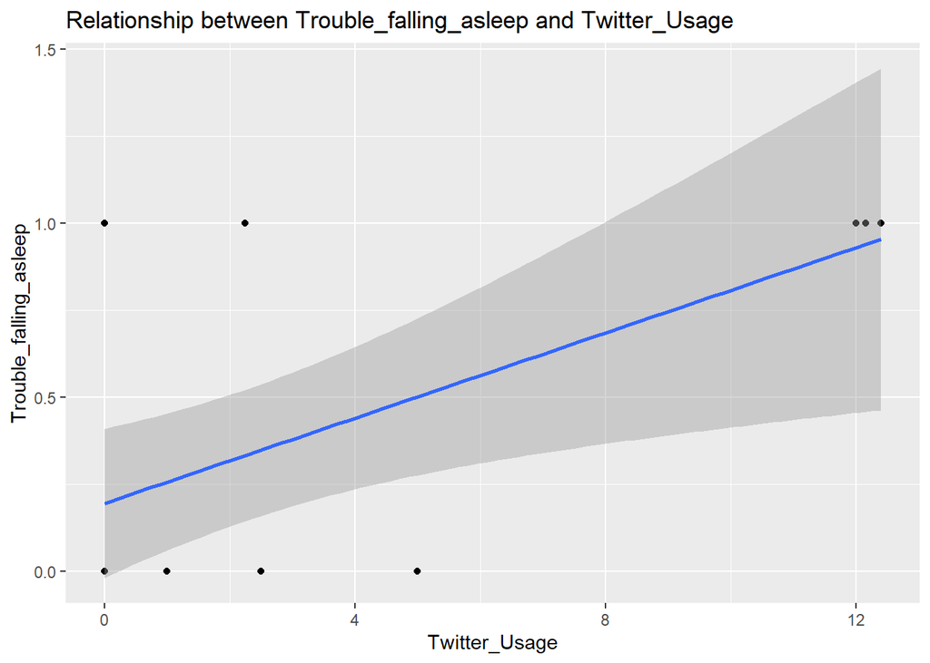

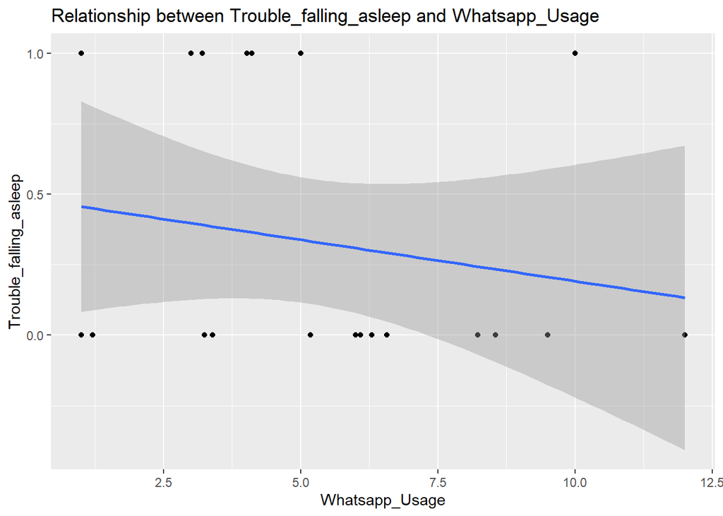

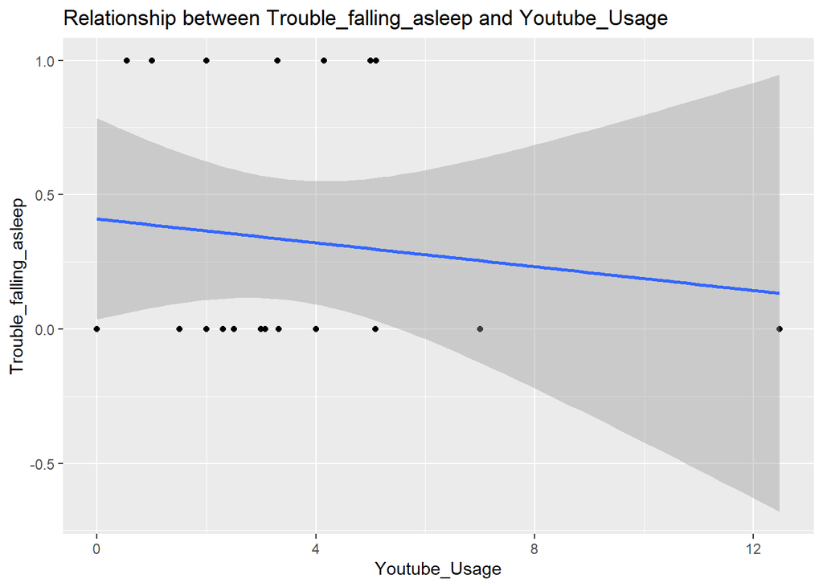

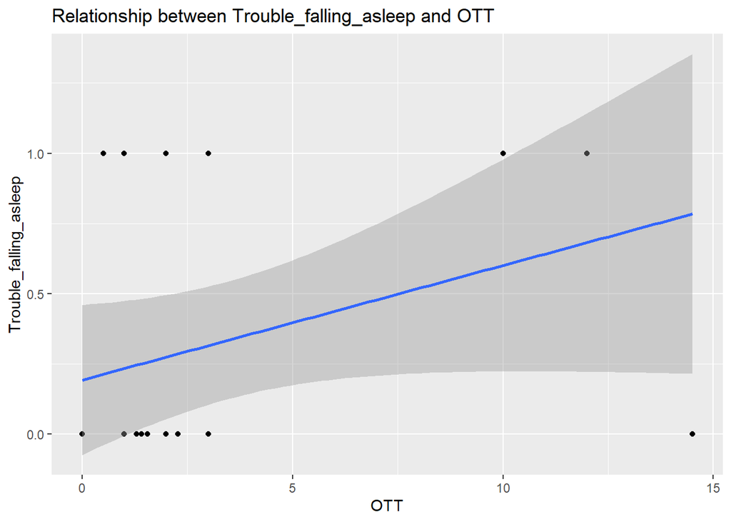

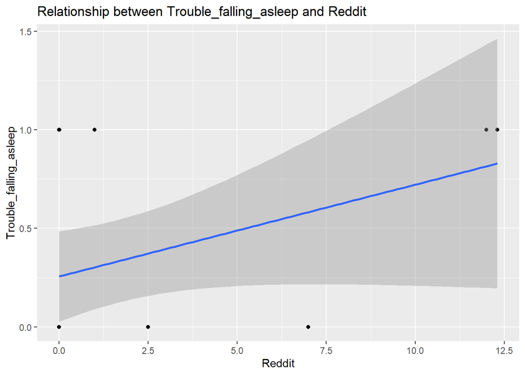

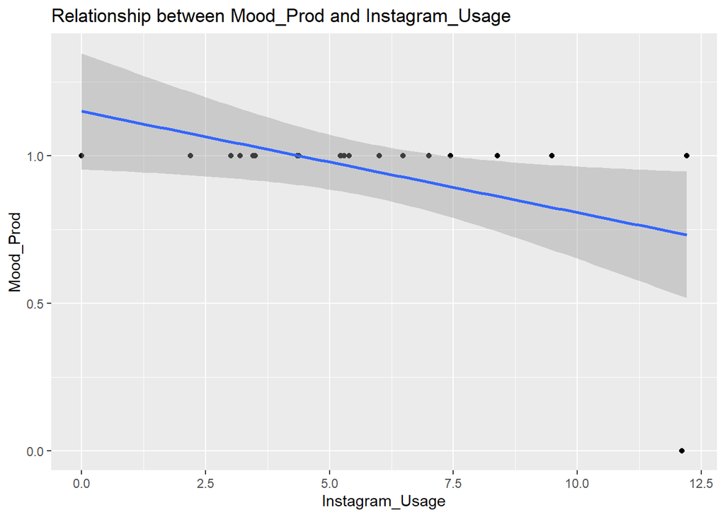

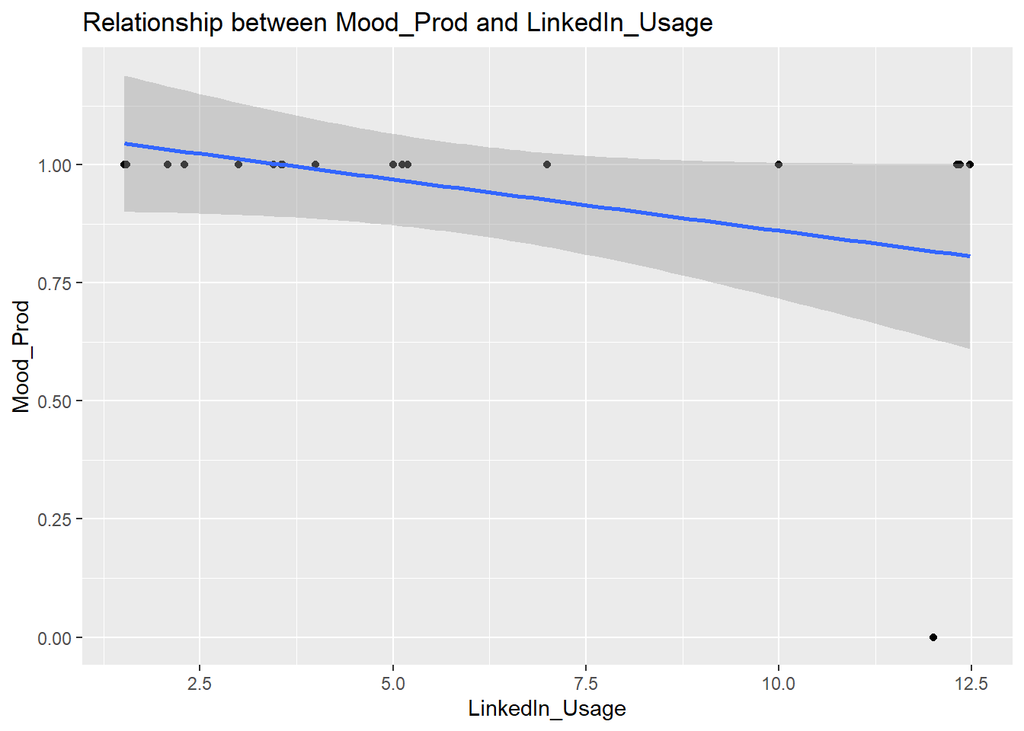

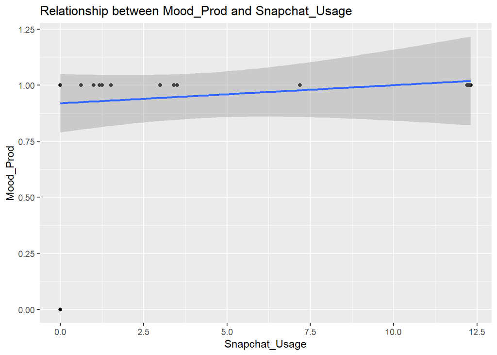

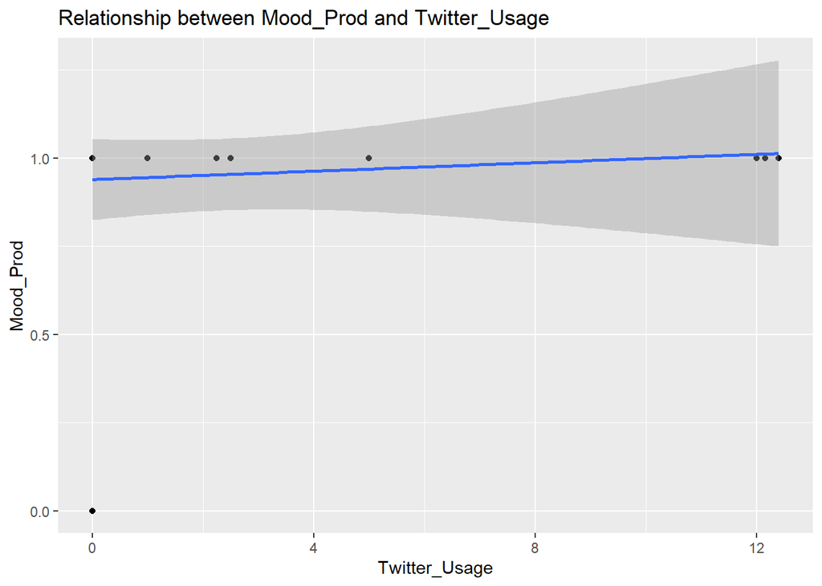

[12 more figures not shown]

```r
# Load necessary libraries if not already loaded
library(ggplot2)

# Define the dependent variables
dependent_variables <- c("Trouble_falling_asleep", "Mood_Prod", "Tired_waking_up_in_morning")

# Define the independent variables
independent_variables <- c("Instagram_Usage", "LinkedIn_Usage", "Snapchat_Usage",
                            "Twitter_Usage", "Whatsapp_Usage", "Youtube_Usage", "OTT", "Reddit")

# Loop through each dependent variable
for (dep_var in dependent_variables) {
  # Loop through each independent variable
  for (ind_var in independent_variables) {
    # Create a scatter plot for the relationship between the dependent and independent variables
    plot <- ggplot(social_media_final, aes_string(x = ind_var, y = dep_var)) +
      geom_point() +
      geom_smooth(method = "lm") +
      labs(title = paste("Relationship between", dep_var, "and", ind_var))

    # Print the plot
    print(plot)
  }
}
```

# Mean and Variance Analysis

```r
mean_var_analysis <- function(data, variable_name) {
  mean_val <- mean(data[[variable_name]])
  var_val <- var(data[[variable_name]])

  cat("Variable:", variable_name, "\n")
  cat("Mean:", mean_val, "\n")
  cat("Variance:", var_val, "\n\n")
}

# Apply the function to each variable
mean_var_analysis(social_media_final, "Instagram_Usage")
```

```
## Variable: Instagram_Usage
## Mean: 5.778571
## Variance: 9.201723
```

```r
mean_var_analysis(social_media_final, "LinkedIn_Usage")
```

```
## Variable: LinkedIn_Usage
## Mean: 5.784286
## Variance: 14.29608
```

```r
mean_var_analysis(social_media_final, "Snapchat_Usage")
```

```
## Variable: Snapchat_Usage
## Mean: 4.04619
## Variance: 24.99824
```

```r
mean_var_analysis(social_media_final, "Twitter_Usage")
```

```
## Variable: Twitter_Usage
## Mean: 2.252857
## Variance: 18.81777
```

```r
mean_var_analysis(social_media_final, "Whatsapp_Usage")
```

```
## Variable: Whatsapp_Usage
## Mean: 5.172381
## Variance: 9.998999
```

```r
mean_var_analysis(social_media_final, "Youtube_Usage")
```

```
## Variable: Youtube_Usage
## Mean: 3.460476
## Variance: 7.060935
```

```r
mean_var_analysis(social_media_final, "OTT")
```

```
## Variable: OTT
## Mean: 3.454762
## Variance: 20.00731
```

```r
mean_var_analysis(social_media_final, "Reddit")
```

```
## Variable: Reddit
## Mean: 1.657619
## Variance: 14.69192
```

```r
mean_var_analysis(social_media_final, "Trouble_falling_asleep")
```

```
## Variable: Trouble_falling_asleep
## Mean: 0.3333333
## Variance: 0.2333333
```

```r
mean_var_analysis(social_media_final, "Mood_Prod")
```

```
## Variable: Mood_Prod
## Mean: 0.952381
## Variance: 0.04761905
```

```r
mean_var_analysis(social_media_final, "Tired_waking_up_in_morning")
```

```
## Variable: Tired_waking_up_in_morning
## Mean: 0.3333333
## Variance: 0.2333333
```

#Perform F-test and t-test

```r
perform_tests <- function(variable_name, data) {
  # Perform F-test
  f_test <- var.test(data[[variable_name]] ~ data$Trouble_falling_asleep)

  # Perform t-test
  t_test <- t.test(data[[variable_name]] ~ data$Trouble_falling_asleep)

  # Print results
  cat("Variable:", variable_name, "\n")
  cat("F-test results:\n")
  cat("  F-statistic:", f_test$statistic, "\n")
  cat("  p-value:", f_test$p.value, "\n\n")
  cat("t-test results:\n")
  cat("  t-statistic:", t_test$statistic, "\n")
  cat("  p-value:", t_test$p.value, "\n\n")
}

# Perform tests for each variable
perform_tests("Instagram_Usage", social_media_final)
```

```
## Variable: Instagram_Usage
## F-test results:
##   F-statistic: 1.407548
##   p-value: 0.7048621
##
## t-test results:
##   t-statistic: 1.026571
##   p-value: 0.321821
```

```r
perform_tests("LinkedIn_Usage", social_media_final)
```

```
## Variable: LinkedIn_Usage
## F-test results:
##   F-statistic: 1.182308
##   p-value: 0.8855713
##
## t-test results:
##   t-statistic: 0.8568985
##   p-value: 0.4069261
```

```r
perform_tests("Snapchat_Usage", social_media_final)
```

```
## Variable: Snapchat_Usage
## F-test results:
##   F-statistic: 0.9254988
##   p-value: 0.8451404
##
## t-test results:
##   t-statistic: -0.9477588
##   p-value: 0.3624443
```

```r
perform_tests("Twitter_Usage", social_media_final)
```

```
## Variable: Twitter_Usage
## F-test results:
##   F-statistic: 0.05308698
##   p-value: 2.046153e-05
##
## t-test results:
##   t-statistic: -2.057799
##   p-value: 0.08293642
```

```r
perform_tests("Whatsapp_Usage", social_media_final)
```

```
## Variable: Whatsapp_Usage
## F-test results:
##   F-statistic: 1.435712
##   p-value: 0.6854257
##
## t-test results:
##   t-statistic: 0.9081149
##   p-value: 0.3788634
```

```r
perform_tests("Youtube_Usage", social_media_final)
```

```
## Variable: Youtube_Usage
## F-test results:
##   F-statistic: 2.614543
##   p-value: 0.2452841
##
## t-test results:
##   t-statistic: 0.6270227
##   p-value: 0.5385795
```

```r
perform_tests("OTT", social_media_final)
```

```
## Variable: OTT
## F-test results:
##   F-statistic: 0.4818352
##   p-value: 0.2541279
##
## t-test results:
##   t-statistic: -1.571152
##   p-value: 0.1506024
```

```r
perform_tests("Reddit", social_media_final)
```

```
## Variable: Reddit
## F-test results:
##   F-statistic: 0.1099967
##   p-value: 0.0009873817
##
## t-test results:
##   t-statistic: -1.295042
##   p-value: 0.238333
```

```r
sm <- read.csv("C:/Users/sakad/Downloads/social_media_cleaned.csv")
str(sm)
```

```
## 'data.frame':    21 obs. of  10 variables:
##  $ character                    : chr  "masinl" "peace" "Patty" "Bunny" ...
##  $ Instagram                    : num  3.5 7.73 3.77 5.38 12 2.33 5.37 7 8.65 0.17 ...
##  $ LinkedIn                     : num  4 5.2 7 5.32 0.58 7 4 4 10 0 ...
##  $ SnapChat                     : num  1 3.68 0.53 1.3 0 0.47 0 3 3.83 0 ...
##  $ Twitter                      : num  5 0 0 0 0.67 0 0 0 0 0 ...
##  $ Whatsapp.Wechat              : num  1 4.18 9.83 5.3 3 12 6 10 6.15 1 ...
##  $ youtube                      : num  2.5 4.25 1.85 2 3.5 7 3 2 4 3 ...
##  $ OTT                          : num  14.5 0 2 2 2 3 0 3 3 0 ...
##  $ Reddit                       : num  2.5 0 0 0 1 0 0 0 0 0 ...
##  $ How.you.felt.the.entire.week.: int  3 3 4 4 3 5 4 4 3 2 ...
```

```r
sm1 <- sm[, 2:9]
sm1
```

```
##    Instagram LinkedIn SnapChat Twitter Whatsapp.Wechat youtube   OTT Reddit
## 1       3.50     4.00     1.00    5.00            1.00    2.50 14.50   2.50
## 2       7.73     5.20     3.68    0.00            4.18    4.25  0.00   0.00
## 3       3.77     7.00     0.53    0.00            9.83    1.85  2.00   0.00
## 4       5.38     5.32     1.30    0.00            5.30    2.00  2.00   0.00
## 5      12.00     0.58     0.00    0.67            3.00    3.50  2.00   1.00
## 6       2.33     7.00     0.47    0.00           12.00    7.00  3.00   0.00
## 7       5.37     4.00     0.00    0.00            6.00    3.00  0.00   0.00
## 8       7.00     4.00     3.00    0.00           10.00    2.00  3.00   0.00
## 9       8.65    10.00     3.83    0.00            6.15    4.00  3.00   0.00
## 10      0.17     0.00     0.00    0.00            1.00    3.00  0.00   0.00
## 11      4.58     2.13     0.42    2.42            1.00    1.00  0.00   0.00
## 12      3.33     2.50     0.33    2.83            3.67    2.50  1.50   0.00
## 13      5.30     1.52    14.87    0.00            4.02    0.54  0.51   0.01
## 14      6.00     3.00     1.00    1.00            3.42    2.50  1.00   0.00
## 15      4.65     3.75     1.42    0.00            6.50    3.13  1.92   7.00
## 16      7.00     5.00     0.42    0.00            5.00    5.00  1.00   0.50
## 17      9.80     0.80     0.00    0.27           13.35    3.53  1.68   0.00
## 18      6.80     1.92     1.87    0.00            6.95    0.80  2.47   0.00
## 19      5.67     3.92     0.00    0.00            8.92    5.15  0.00   0.00
## 20     15.02     3.95     7.32    0.00           15.35    5.17 10.00   0.00
## 21      0.33     0.52     0.00    0.00            8.38    0.00  0.00   0.00
```

PCA Q: How do relation between social media platforms inform our understanding of user behavior and interactions?

```r
#Get the correlations between the variables
cor(sm1, use = "complete.obs")
```

```
##                   Instagram     LinkedIn    SnapChat    Twitter Whatsapp.Wechat
## Instagram        1.00000000  0.096836443  0.28970103 -0.1927972      0.37784893
## LinkedIn         0.09683644  1.000000000  0.02529643 -0.1306175      0.22899698
## SnapChat         0.28970103  0.025296428  1.00000000 -0.1801613      0.08104862
## Twitter         -0.19279717 -0.130617547 -0.18016133  1.0000000     -0.49574787
## Whatsapp.Wechat  0.37784893  0.228996980  0.08104862 -0.4957479      1.00000000
## youtube          0.33021732  0.452160243 -0.15977901 -0.1881819      0.37182165
## OTT              0.26738411  0.185463793  0.13165277  0.5569830      0.13356020
## Reddit          -0.07458765 -0.007079162 -0.08096904  0.1649095     -0.13445849
##                     youtube       OTT       Reddit
## Instagram        0.33021732 0.2673841 -0.074587647
## LinkedIn         0.45216024 0.1854638 -0.007079162
## SnapChat        -0.15977901 0.1316528 -0.080969036
## Twitter         -0.18818187 0.5569830  0.164909542
## Whatsapp.Wechat  0.37182165 0.1335602 -0.134458488
## youtube          1.00000000 0.1607195  0.026007762
## OTT              0.16071951 1.0000000  0.232981971
## Reddit           0.02600776 0.2329820  1.000000000
```

The result is a correlation matrix showing the relationships between different social media platforms based on their usage patterns or user engagement. Each cell in the matrix represents the correlation coefficient between pairs of platforms, ranging from -1 to 1. A value of 1 indicates a perfect positive correlation (when one platform’s usage increases, the other’s also tends to increase), while -1 indicates a perfect negative correlation (when one platform’s usage increases, the other’s tends to decrease).

For instance, the correlation between Instagram and LinkedIn is 0.097, suggesting a weak positive correlation, implying that users who engage more with Instagram may also have a slight tendency to engage more with LinkedIn. Conversely, the correlation between Twitter and Whatsapp/Wechat is -0.496, indicating a moderate negative correlation, implying that users who are highly active on Twitter may be less active on Whatsapp/Wechat, and vice versa.

The diagonal elements (where the platform is compared to itself) always have a correlation coefficient of 1 since a platform perfectly correlates with itself. This matrix helps understand how different social media platforms are related to each other in terms of user engagement or usage patterns, which can be valuable for marketers, researchers, and social media strategists in understanding user behavior and optimizing their strategies across multiple platforms.

Q: What are the implications of the rotated factor loadings on social media platforms in understanding their associations and contributions to different dimensions captured by principal components in factor analysis or principal component analysis?

```r
#Computing Principal Components
social_pca <- prcomp(sm1,scale=TRUE)
social_pca
```

```
## Standard deviations (1, .., p=8):
## [1] 1.4937855 1.3062652 1.1302644 0.9384154 0.9007773 0.7693882 0.6079359
## [8] 0.3622309
##
## Rotation (n x k) = (8 x 8):
##                         PC1         PC2          PC3         PC4         PC5
## Instagram        0.43528749 -0.15383754  0.378064635  0.03091067  0.36691411
## LinkedIn         0.35654047 -0.20942720 -0.329973958 -0.19635277 -0.70307433
## SnapChat         0.15951942  0.03373703  0.717834288  0.10382304 -0.50998908
## Twitter         -0.39042544 -0.53811531  0.040061762 -0.33459600  0.09394086
## Whatsapp.Wechat  0.52692924  0.06069670  0.007260553  0.09076207  0.28302310
## youtube          0.45376608 -0.20713849 -0.406499207 -0.03646460  0.09495664
## OTT              0.08164899 -0.68438404  0.215954720 -0.12833890  0.07485857
## Reddit          -0.12369550 -0.35608430 -0.139149370  0.90095400 -0.08616338
##                         PC6         PC7         PC8
## Instagram       -0.51106683 -0.48946149  0.08707842
## LinkedIn         0.02588829 -0.42218323  0.09143040
## SnapChat        -0.04950250  0.39275988  0.17478671
## Twitter         -0.02565582  0.04598525  0.65790782
## Whatsapp.Wechat  0.68945551  0.02304825  0.39292343
## youtube         -0.39820221  0.64499580  0.03189625
## OTT              0.31729474  0.06579314 -0.59265177
## Reddit          -0.02102173 -0.07024430  0.11841633
```

These loadings represent the correlation between each social media platform and the identified components. Higher absolute values (close to 1) suggest a stronger relationship, while values closer to 0 indicate a weaker association. The rotated factor loadings help in interpreting the underlying structure of the data, revealing which social media platforms are closely related and how they contribute to different dimensions captured by the principal components.

```r
summary(social_pca)
```

```
## Importance of components:
##                           PC1    PC2    PC3    PC4    PC5     PC6    PC7    PC8
## Standard deviation     1.4938 1.3063 1.1303 0.9384 0.9008 0.76939 0.6079 0.3622
## Proportion of Variance 0.2789 0.2133 0.1597 0.1101 0.1014 0.07399 0.0462 0.0164
## Cumulative Proportion  0.2789 0.4922 0.6519 0.7620 0.8634 0.93740 0.9836 1.0000
```

```r
eigen_social<- social_pca$sdev^2
eigen_social
```

```
## [1] 2.2313950 1.7063288 1.2774976 0.8806234 0.8113997 0.5919581 0.3695861
## [8] 0.1312112
```

The PCA analysis reveals that PC1 and PC2 together contribute approximately 50% of the total variance.

Q: What the variance explained by each component, and how does it suggest the number of components to retain for analysis?

Screeplot

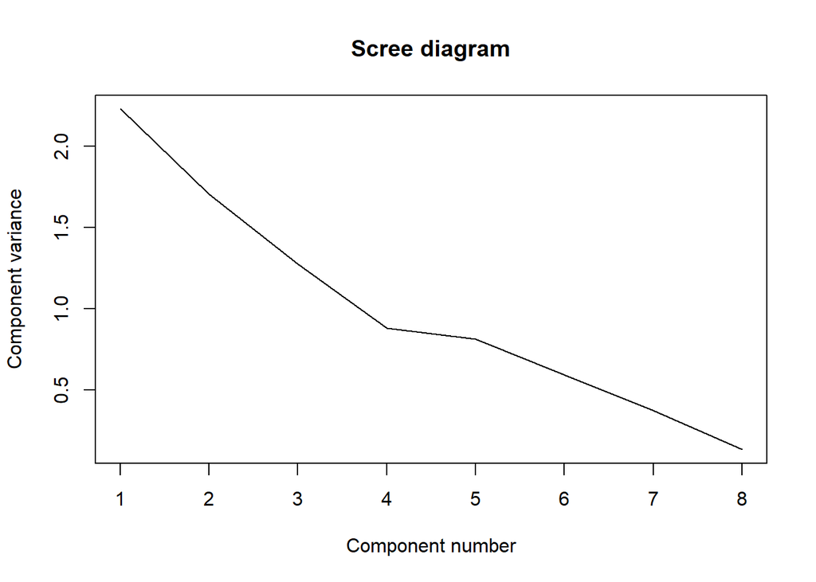

```r
plot(eigen_social, xlab = "Component number", ylab = "Component variance", type = "l", main = "Scree diagram")
```

From this Scree diagram, we can see that the first component has a variance just above 2.0, and the variance decreases with each additional component. The curve starts to flatten out after the third component, suggesting that retaining the first two or three components might be appropriate for this particular analysis. Components beyond this point are often considered to contribute less to explaining the variance and may be less meaningful.

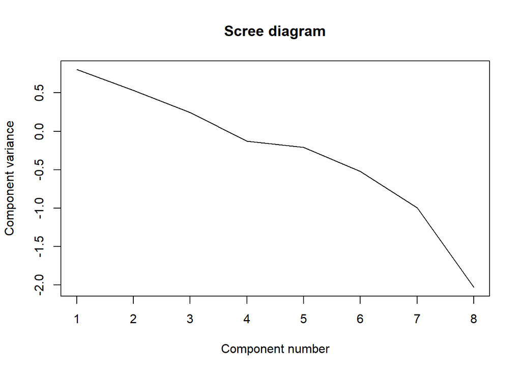

```r
plot(log(eigen_social), xlab = "Component number", ylab = "Component variance", type = "l", main = "Scree diagram")
```

Visualization using Principal Components

```r
library(FactoMineR)
library("factoextra")
```

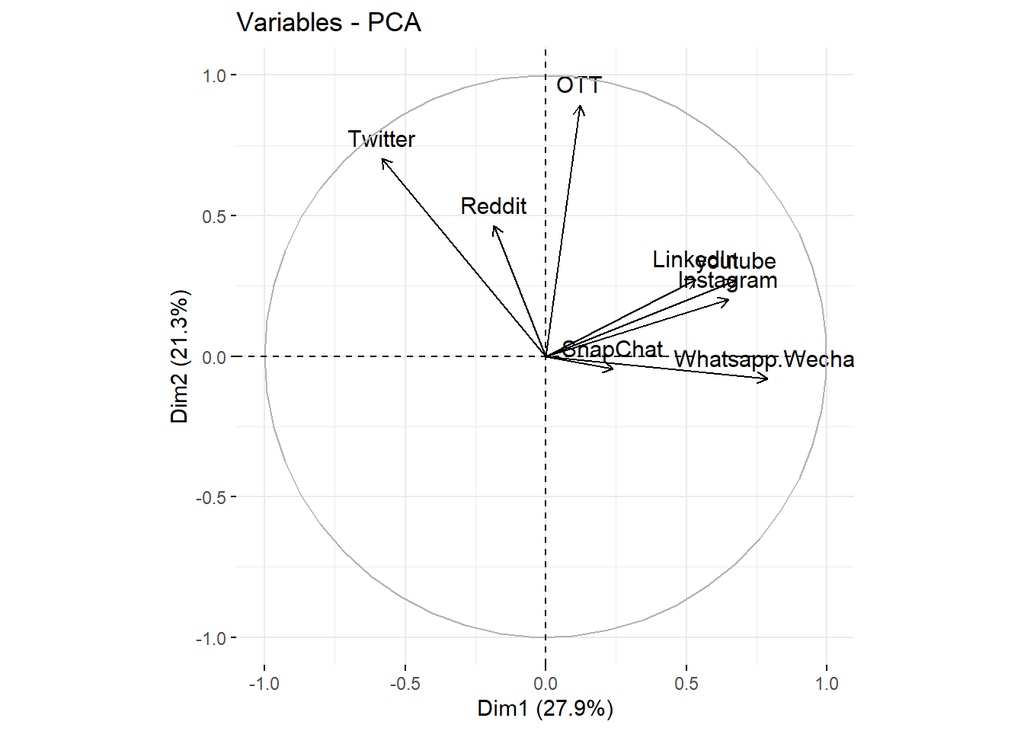

```r
res.pca <- PCA(sm1, graph = FALSE)
fviz_pca_var(res.pca, col.var = "black")
```

Factor Analysis

```r
# load library for factor analysis
library(ggplot2)
library(psych)
```

Q: Determine the optimal number of factors for your dataset?

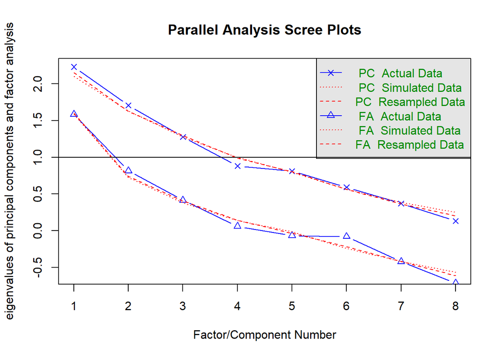

```
## Parallel analysis suggests that the number of factors =  0  and the number of components =  0
```

```r
fa.parallel(sm1)
```

Parallel analysis indicates that both the number of factors and the number of components are zero.

Q: Provide an explanation for the output of your factor model?

```r
fit.pc <- principal(sm1, nfactors=2, rotate="varimax")
fit.pc
```

```
## Principal Components Analysis
## Call: principal(r = sm1, nfactors = 2, rotate = "varimax")
## Standardized loadings (pattern matrix) based upon correlation matrix
##                   RC1   RC2    h2   u2 com
## Instagram        0.68  0.01 0.463 0.54 1.0
## LinkedIn         0.59  0.11 0.358 0.64 1.1
## SnapChat         0.22 -0.11 0.059 0.94 1.5
## Twitter         -0.36  0.84 0.834 0.17 1.4
## Whatsapp.Wechat  0.73 -0.30 0.626 0.37 1.3
## youtube          0.73  0.07 0.533 0.47 1.0
## OTT              0.37  0.82 0.814 0.19 1.4
## Reddit          -0.04  0.50 0.250 0.75 1.0
##
##                        RC1  RC2
## SS loadings           2.19 1.75
## Proportion Var        0.27 0.22
## Cumulative Var        0.27 0.49
## Proportion Explained  0.56 0.44
## Cumulative Proportion 0.56 1.00
##
## Mean item complexity =  1.2
## Test of the hypothesis that 2 components are sufficient.
##
## The root mean square of the residuals (RMSR) is  0.13
##  with the empirical chi square  21.05  with prob <  0.072
##
## Fit based upon off diagonal values = 0.71
```

- Large absolute values (near 1) signify a robust association between the variable and the factor.
- h2 quantifies the extent to which factors account for variable variance.
- u2 denotes the portion of variance not captured by the factors.

Principal Components Analysis Call: principal(r = sm1, nfactors = 2, rotate = “varimax”) Standardized loadings (pattern matrix) based upon correlation matrix

[output not shown]

```r
round(fit.pc$values, 3)
```

```
## [1] 2.231 1.706 1.277 0.881 0.811 0.592 0.370 0.131
```

```r
fit.pc$loadings
```

```
##
## Loadings:
##                 RC1    RC2
## Instagram        0.681
## LinkedIn         0.588  0.111
## SnapChat         0.216 -0.110
## Twitter         -0.359  0.840
## Whatsapp.Wechat  0.732 -0.300
## youtube          0.727
## OTT              0.371  0.822
## Reddit                  0.498
##
##                  RC1   RC2
## SS loadings    2.189 1.749
## Proportion Var 0.274 0.219
## Cumulative Var 0.274 0.492
```

```r
# Communalities
fit.pc$communality
```

```
##       Instagram        LinkedIn        SnapChat         Twitter Whatsapp.Wechat
##       0.4631760       0.3584966       0.0587232       0.8342344       0.6258430
##         youtube             OTT          Reddit
##       0.5326647       0.8140886       0.2504973
```

```r
# Rotated factor scores, Notice the columns ordering: RC1, RC2
fit.pc
```

```
## Principal Components Analysis
## Call: principal(r = sm1, nfactors = 2, rotate = "varimax")
## Standardized loadings (pattern matrix) based upon correlation matrix
##                   RC1   RC2    h2   u2 com
## Instagram        0.68  0.01 0.463 0.54 1.0
## LinkedIn         0.59  0.11 0.358 0.64 1.1
## SnapChat         0.22 -0.11 0.059 0.94 1.5
## Twitter         -0.36  0.84 0.834 0.17 1.4
## Whatsapp.Wechat  0.73 -0.30 0.626 0.37 1.3
## youtube          0.73  0.07 0.533 0.47 1.0
## OTT              0.37  0.82 0.814 0.19 1.4
## Reddit          -0.04  0.50 0.250 0.75 1.0
##
##                        RC1  RC2
## SS loadings           2.19 1.75
## Proportion Var        0.27 0.22
## Cumulative Var        0.27 0.49
## Proportion Explained  0.56 0.44
## Cumulative Proportion 0.56 1.00
##
## Mean item complexity =  1.2
## Test of the hypothesis that 2 components are sufficient.
##
## The root mean square of the residuals (RMSR) is  0.13
##  with the empirical chi square  21.05  with prob <  0.072
##
## Fit based upon off diagonal values = 0.71
```

```r
fit.pc$scores
```

```
##               RC1         RC2
##  [1,] -0.49624055  3.81931118
##  [2,]  0.37381791 -0.45829983
##  [3,]  0.24026578 -0.39773035
##  [4,] -0.11813877 -0.28581917
##  [5,] -0.05612179  0.18892772
##  [6,]  1.33950136 -0.15489910
##  [7,] -0.16510634 -0.57411254
##  [8,]  0.36248103 -0.37606120
##  [9,]  1.27363310  0.04673432
## [10,] -1.47442593 -0.57714722
## [11,] -1.47172675  0.33207687
## [12,] -0.99536049  0.65208895
## [13,] -0.64535181 -0.84676594
## [14,] -0.54371772 -0.04386217
## [15,] -0.05085497  0.89227335
## [16,]  0.46515473 -0.19348386
## [17,]  0.63768723 -0.56192633
## [18,] -0.42546987 -0.44047678
## [19,]  0.50443809 -0.59824502
## [20,]  2.63331377  0.51395273
## [21,] -1.38777801 -0.93653561
```

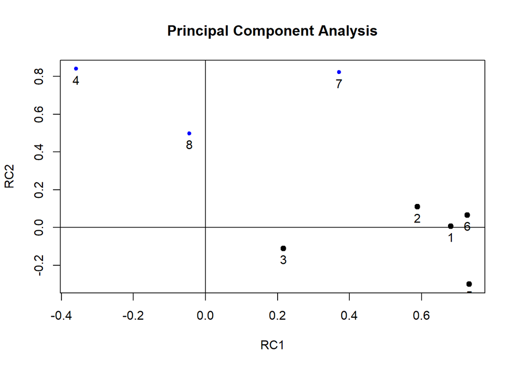

```r
fa.plot(fit.pc) # See Correlations within Factors
```

Q: Show the columns that go into each factor?

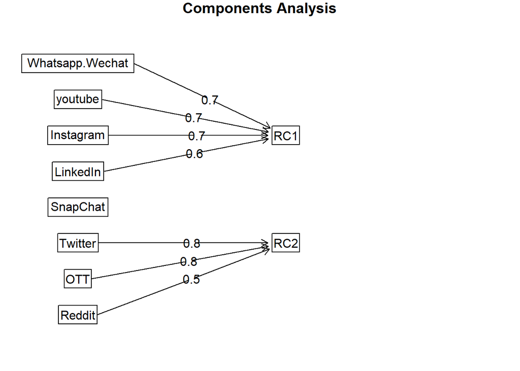

```r
fa.diagram(fit.pc) # Visualize the relationship
```

This displays a diagram titled “Components Analysis,” which seems to represent a factor analysis or a similar statistical method that groups different social media platforms into components based on their relationships. The platforms listed are WhatsApp/WeChat, YouTube, Instagram, LinkedIn, SnapChat, Twitter, OTT, and Reddit.

Creating visual representations utilizing the factors.

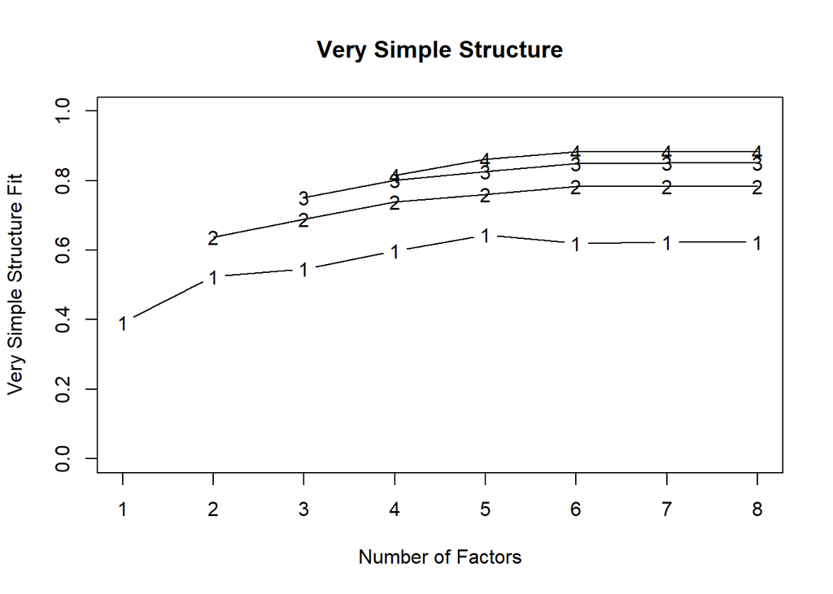

```
##
## Very Simple Structure
## Call: vss(x = sm1)
## VSS complexity 1 achieves a maximimum of 0.64  with  5  factors
## VSS complexity 2 achieves a maximimum of 0.78  with  7  factors
##
## The Velicer MAP achieves a minimum of 0.07  with  1  factors
## BIC achieves a minimum of  -35.55  with  1  factors
## Sample Size adjusted BIC achieves a minimum of  1.71  with  4  factors
##
## Statistics by number of factors
##   vss1 vss2   map dof   chisq prob sqresid  fit RMSEA   BIC SABIC complex
## 1 0.39 0.00 0.071  20 2.5e+01 0.19     7.0 0.39   0.1 -35.6  26.2     1.0
## 2 0.52 0.64 0.090  13 8.9e+00 0.78     4.2 0.64   0.0 -30.7   9.4     1.2
## 3 0.55 0.69 0.117   7 4.7e+00 0.70     2.9 0.75   0.0 -16.6   5.0     1.5
## 4 0.60 0.74 0.179   2 1.6e+00 0.44     2.1 0.81   0.0  -4.5   1.7     1.5
## 5 0.64 0.76 0.271  -2 6.5e-01   NA     1.5 0.87    NA    NA    NA     1.3
## 6 0.62 0.78 0.442  -5 4.5e-10   NA     1.2 0.90    NA    NA    NA     1.5
## 7 0.62 0.78 1.000  -7 0.0e+00   NA     1.2 0.90    NA    NA    NA     1.5
## 8 0.62 0.78    NA  -8 0.0e+00   NA     1.2 0.90    NA    NA    NA     1.5
##    eChisq    SRMR eCRMS  eBIC
## 1 3.2e+01 1.7e-01 0.196 -28.5
## 2 9.2e+00 8.8e-02 0.130 -30.4
## 3 2.1e+00 4.2e-02 0.084 -19.2
## 4 8.0e-01 2.6e-02 0.097  -5.3
## 5 2.2e-01 1.4e-02    NA    NA
## 6 1.8e-10 3.9e-07    NA    NA
## 7 2.2e-18 4.3e-11    NA    NA
## 8 2.2e-18 4.3e-11    NA    NA
```

```r
#very simple structure visualization
vss(sm1)
```

```r
# Computing Correlation Matrix
corrm.social <- cor(sm1)
corrm.social
```

```
##                   Instagram     LinkedIn    SnapChat    Twitter Whatsapp.Wechat
## Instagram        1.00000000  0.096836443  0.28970103 -0.1927972      0.37784893
## LinkedIn         0.09683644  1.000000000  0.02529643 -0.1306175      0.22899698
## SnapChat         0.28970103  0.025296428  1.00000000 -0.1801613      0.08104862
## Twitter         -0.19279717 -0.130617547 -0.18016133  1.0000000     -0.49574787
## Whatsapp.Wechat  0.37784893  0.228996980  0.08104862 -0.4957479      1.00000000
## youtube          0.33021732  0.452160243 -0.15977901 -0.1881819      0.37182165
## OTT              0.26738411  0.185463793  0.13165277  0.5569830      0.13356020
## Reddit          -0.07458765 -0.007079162 -0.08096904  0.1649095     -0.13445849
##                     youtube       OTT       Reddit
## Instagram        0.33021732 0.2673841 -0.074587647
## LinkedIn         0.45216024 0.1854638 -0.007079162
## SnapChat        -0.15977901 0.1316528 -0.080969036
## Twitter         -0.18818187 0.5569830  0.164909542
## Whatsapp.Wechat  0.37182165 0.1335602 -0.134458488
## youtube          1.00000000 0.1607195  0.026007762
## OTT              0.16071951 1.0000000  0.232981971
## Reddit           0.02600776 0.2329820  1.000000000
```